# FoRt: Debugging – Tools

## Verortung: Call Stack ermitteln

Immer ein guter erster Schritt:

`traceback()`: Welche Funktionsaufrufe haben den Fehler ausgelöst?

(setze `options(deparse.max.lines=5)` um Output lesbar zu halten)

## `traceback()`

```r
f <- function(a) g(a)
g <- function(b) h(b)
h <- function(c) i(c)
i <- function(d) "a" + d
f(10)
```

```
Error in "a" + d : non-numeric argument to binary operator
```

```r
traceback()
```

```
4: i(c) at traceback-1.R#3
3: h(b) at traceback-1.R#2
2: g(a) at traceback-1.R#1
1: f(10) at traceback-1.R#5
```

## `traceback()`

```
4: i(c) at traceback-1.R#3
3: h(b) at traceback-1.R#2
2: g(a) at traceback-1.R#1
1: f(10) at traceback-1.R#5
```

- Kette der *execution environments*: *call stack*
- Code der per `source()` geladen wurde mit `Dateiname#Zeilennummer`

## Interaktiver Debugger

- `debug(<function>)`, `debugonce(<function>)`: interaktiver Debugger öffnet sich sobald die Funktion aufgerufen wird. `undebug(<function>)` um *debug mode* wieder zu deaktivieren.
- in eigenen Skripten: Einfügen von `browser()`-statements.  
  (in RStudio: Breakpoint setzen direkt im Editor)
- eigener oder fremder (package) Code: `trace(<broken_function>, edit = TRUE)`, dann Einfügen von `browser()` an geeigneter Stelle

## Interaktiver Debugger

- interaktive Konsole innerhalb der Funktion
- führe beliebigen R Code in der Konsole im *evaluation frame* des Funktionsaufrufes aus.

```r
debug(f)
f(10)
```

```
debugging in: f(10)
debug: g(a)
Browse[2]>
```

## Interaktiver Debugger: Wichtige spezielle Befehle

- `n`, `<enter>`: führe nächsten Befehl der Funktion aus. `print(n)` um lokale Variable `n` auszugeben, falls vorhanden.
- `c`: führe den gesamten aktuellen Codeblock aus:
  - nützlich innerhalb von Schleifen: kein manuelles Steppen durch jede einzelne Iteration
  - nützlich um zu überprüfen ob Funktion komplett & korrekt durchläuft nachdem unerwünschte Variablenwerte manuell im Debugger korrigiert wurden
- `s`: führe den nächsten Befehl aus und debugge die dabei aufgerufene Funktion
- `Q`: stoppt den Debugger, beendet Funktionsauswertung und geht zurück in die normale Konsole.
- sinnvoller erster Schritt im Debugger: `ls.str()` für Übersicht über lokale Variablen und ihre Werte (in RStudio: Environment-Panel)

## Interaktiver Debugger

- `options(error=recover)`: springt in den interaktiven Debugger direkt bevor der Fehler ausgelöst wird. Höchst empfehlenswert.

```r
options(error=recover)
f(10)
```

```
Error in "a" + d : non-numeric argument to binary operator

Enter a frame number, or 0 to exit

1: f(10)
2: traceback-1.R#1: g(a)
3: traceback-1.R#2: h(b)
4: traceback-1.R#3: i(c)

Selection:
```

## Verortung

- `error=recover()`-option abschalten mit

```r
# default wiederherstellen:
options(error=NULL)
# oder:
options(error=traceback)
```

- nicht empfehlenswert:  
  Code mit vielenvielen `print`, `cat`, etc. Befehlen “verzieren” um z.B Variablenwerte nachzuverfolgen

## Debugging in RStudio

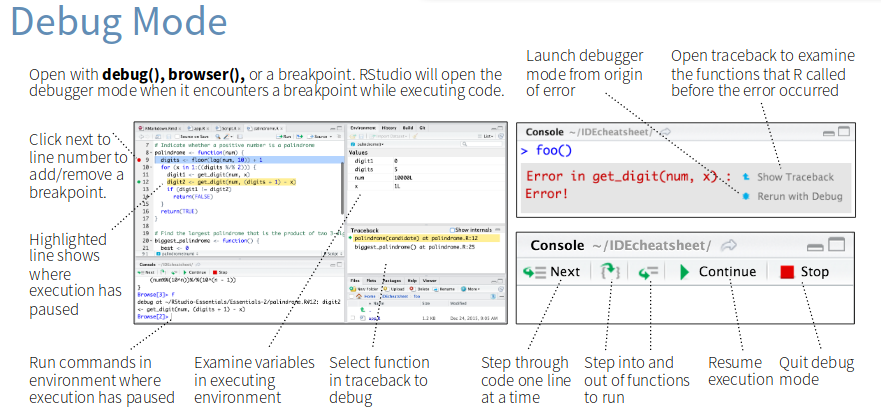

Quelle: github.com/rstudio/cheatsheets/raw/master/rstudio-ide.pdf

## Debugging in RStudio

- öffnet automatisch neues Tab mit Quellcode der Funktion die gerade im Debugger ist
- “Environment” Panel zeigt Zustand der Variablen an  
  (entspricht in etwa Output von `ls.str`)

[Videotutorial (11 min)](https://vimeo.com/99375765)

## Debugging *workflow*

- **lies die Fehlermeldung.** Echt jetzt.
- lies die Fehlermeldung *nochmal*. Denk drüber nach.
- noch kein Plan? Rufe `traceback()`
- immer noch kein Plan? Lies die Hilfe der Funktion die den Fehler ausgibt.

## Debugging *workflow*

Immer noch kein Plan? Springe an die Stelle im Code die den Fehler auslöst um genauer nachzusehen:

- setze `options(error=recover, deparse.max.lines=5)`
- lass den Code der den Fehler getriggert hat nochmal laufen
- wähle geeigneten *frame* (nicht zu niedrig im *call stack*, nicht zu hoch…)
- schau den Zustand der lokalen Variablen bei Auslösung des Fehlers an: `ls.str()` bzw. Environment Panel in RStudio
- lies den Quellcode der Funktion um zu verstehen was der Zustand der lokalen Variablen an dieser Stelle im Programm sein **sollte**
- hilft alles nüscht? Fang von vorne an, wähle anderen *frame* aus dem *call stack*

## Debugging: Code in (CRAN) Paketen

Wie komme ich an den Quellcode von Paketen?

1. Gebe Namen der Funktion in die Konsole ein (Keine Kommentare, nicht so ganz einfach für S3/S4 Methoden und nicht-exportierte Funktionen.)
2. Lade `<PAKET>.tar.gz` von CRAN/R-forge/Bioconductor/etc. herunter, extrahiere lokal und durchsuche Dateien im `/R`-Verzeichnis
3. **Gehe auf `https://github.com/cran/<PAKET>`, benutze Github-Suchfunktion**

Auch hilfreich: installiere das [{`lookup`}](https://github.com/jimhester/lookup)-Paket von Jim Hester.

## Untersuchung unerwarteter Warnungen

- konvertiere Warnungen in Fehler mit `options(warn = 2)`
- benutze übliche *debugging* Werkzeuge (`traceback`, `options(error=recover)`, …)